# Python en TP de Physique-Chimie

## Table des matières

- 1. Importer des données depuis un tableur
- 2. Tracer une courbe avec les incertitudes
- 3. Réaliser une modélisation via Python
- 1. Propager les incertitudes avec Monte-Carlo
- 1. Evaluer l'incertitude-type sur un paramètre inconnu avec Monte-Carlo
- 1. Rechercher le zéro d'une fonction
- 1. Résoudre un équation différentielle

## 1. Importer des données depuis un tableur

Retour à la table des matières

Vous avez réalisé un jeu de mesures sur un tableur et avez obtenu un fichier type ".xls" ou ".xlsx" à l'aide d'Excel ou Libre Office.

**Comment l'importer rapidement sur Python ?**

Nous allons pour cela utiliser les modules :

- `pandas` pour l'import des données depuis le tableur
- `matplotlib.pyplot` pour les tracés
- `numpy`pour le traitement des tableaux

```python
import pandas as pd
import numpy as np
import matplotlib.pyplot as plt
```

Dans un premier temps, on récupère les données qui sont dans le tableur. Une bonne pratique est que chaque grandeur corresponde à une colonne du tableur, et que la première ligne corresponde au nom de la grandeur et à son unité. Par exemple, dans notre fichier `determinationg.xls`, les trois premières lignes sont :

| $$\Delta t \mbox{ (s) }$$ | $$u(\Delta t) \mbox{ (s) }$$ | $$h \mbox{ (m) }$$ | $$u(h) \mbox{ (m) }$$ |
| --- | --- | --- | --- |
| 0,25 | 0,05 | 0,5 | 0,02 |
| 0,42 | 0,05 | 0,75 | 0,02 |

On va importer les données du tableur dans Python sous la forme d'un `DataFrame`, appelé `mesdonnees` ci-dessous, à l'aide de la fonction `read_excel`:

```python
mesdonnees = pd.read_excel("determinationg.xls")
# si le chemin relatif ne fonctionne pas, vous pouvez indiquer le chemin absolu
# avec des // comme "C://Users//etc//monfichier.xlsx"
```

Il ne reste plus désormais qu'à récupérer chaque colonne du tableur sous forme d'un tableau `numpy` à l'aide de la méthode `values` suivante :

```python
deltat=mesdonnees.values[:,0]
# les : indiquent que l'on prend toutes les lignes,
# le deuxième argument indique la colonne, la première étant repérée par 0
u_deltat=mesdonnees.values[:,1]
h=mesdonnees.values[:,2]
u_h=mesdonnees.values[:,3]
```

On peut vérifier que l'on a bien récupéré ce que l'on voulait :

```python
deltat
```

```
array([0.25, 0.42, 0.5 , 0.53, 0.53, 0.58, 0.72, 0.6 , 0.8 , 0.7 , 0.7 ])
```

```python
u_deltat
```

```
array([0.05, 0.05, 0.05, 0.05, 0.05, 0.05, 0.05, 0.05, 0.05, 0.05, 0.05])
```

```python
h
```

```
array([0.5 , 0.75, 1.  , 1.25, 1.5 , 1.75, 2.  , 2.25, 2.5 , 2.75, 3.  ])
```

```python
u_h
```

```
array([0.02, 0.02, 0.02, 0.02, 0.02, 0.02, 0.02, 0.02, 0.02, 0.02, 0.02])
```

## 2. Tracer une courbe avec les incertitudes

Retour à la table des matières

On s'intéresse à la durée d'une chute libre en fonction de la hauteur du lâché. On a réalisé des expériences et on dispose de 4 tableaux `numpy` depuis un tableur :

- `h` les hauteurs de lâché en m
- `u_h` les incertitudes type associées en m
- `deltat` les durées de chute en s *`u_deltat` les incertitudes type associées en s

**Comment tracer de manière élégante $\Delta t(h)$ en faisant apparaître les incertitudes type ?**

Nous allons utiliser pour cela le module `matplotlib.pyplot`.

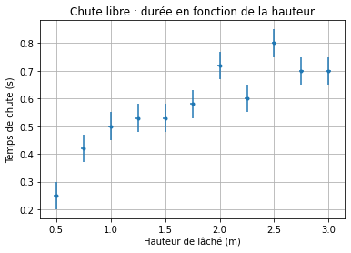

```python
import matplotlib.pyplot as plt

plt.figure() #créeons une nouvelle figure
plt.errorbar(h,deltat,xerr=u_h,yerr=u_deltat,fmt='.') #les incertitudes type sont placées dans les arguments xerr et yerr
# fmt='.' permet de ne pas relier les points (chaque mesure est un point + barre d'incertitude)
plt.grid(which='both') #on ajoute des grilles verticales et horizontales
plt.xlabel("Hauteur de lâché (m)") #on nomme l'axe horizontal
plt.ylabel("Temps de chute (s)") #on nomme l'axe vertical
plt.title("Chute libre : durée en fonction de la hauteur") # titre (optionnel)
plt.show()
```

## 3. Réaliser une modélisation via Python

Retour à la table des matières

On s'intéresse à la durée d'une chute libre en fonction de la hauteur du lâché. On a réalisé des expériences et on dispose de 4 tableaux `numpy` depuis un tableur :

- `h` les hauteurs de lâché en m
- `u_h` les incertitudes type associées en m
- `deltat` les durées de chute en s *`u_deltat` les incertitudes type associées en s

Dans la partie précédente, on a fait le tracé de $\Delta t$ en fonction de h. On sait que l'expression théorique associée est : $$\Delta t = \sqrt{\frac{2h}{g}}$$ où $g$ est le champ de pesanteur.

On va demander à Python de faire de trouver la courbe dont l'équation est la précédente, et qui passe au mieux par les points de mesure. Il en déduira alors la valeur de $g$.

Voici la démarche générale :

```python
from scipy.optimize import curve_fit

def f(x,a,b,c,d): # mettre la variable puis les paramètres à estimer en argument.
return a*x**3+b*x**2+c*x+d # mettre ici l'expression à approcher

x = [...] # rentrer ici la liste des mesures de x
y = [...] # rentrer ici la liste des mesures de y associées

p_estimation,p_err=curve_fit(f, x, y)  #p_estimation est la liste des paramètres estimés
p_type=np.sqrt(np.diag(p_err)) #p_type est la liste des incertitudes type sur l'estimation des paramètres

## ne pas oublier de finir par un tracé superposant les points de mesure et la courbe théorique estimée pour valider
## l'estimation.

## si la modélisation ne converge pas, on peut « aider » curve_fit, en lui donnant une première estimation des
## paramètres dans un argument p0=[aestime,bestime,cestime,destime]
```

Mettons la en application sur notre exemple :

```python
from scipy.optimize import curve_fit # c'est la fonction qui réalise l'ajustement
from math import sqrt

#tout d'abord on définit la fonction à modéliser

def f(x,g):
    return np.sqrt(2*x/g)

x=h
y=deltat

p_estimation,p_err=curve_fit(f, x, y)  #p_estimation est la liste des paramètres estimés
p_type=np.sqrt(np.diag(p_err)) #p_type est la liste des incertitudes type sur l'estimation des paramètres
```

Vérifions la valeur de g, ainsi que le tracé de la courbe modèle :

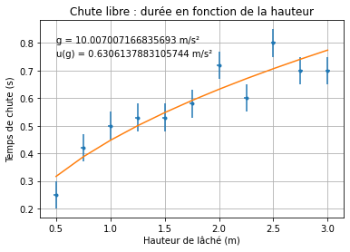

```python
g=p_estimation[0]
u_g=p_type[0]

#le tracé de nos mesures (cf chapitre précédent)
plt.figure()
plt.errorbar(h,deltat,xerr=u_h,yerr=u_deltat,fmt='.')
plt.grid(which='both') #on ajoute des grilles verticales et horizontales
plt.xlabel("Hauteur de lâché (m)") #on nomme l'axe horizontal
plt.ylabel("Temps de chute (s)") #on nomme l'axe vertical
plt.title("Chute libre : durée en fonction de la hauteur") # titre (optionnel)

#le tracé de la modélisation
plt.plot(h,f(h,g))
plt.text(0.5,0.8,"g = "+str(g)+" m/s²")
plt.text(0.5,0.75,"u(g) = "+str(u_g)+" m/s²")

plt.show()
```

Avant d'accepter les valeurs déterminées par la modélisation on vérifie :

- que les points de mesure sont aléatoirement répartis autour de la courbe de modélisation : ok
- que la courbe est toujours "à proximité" des points (pas plus de 2 écarts-types) : ok, même si tout juste

Dans ce cas, on peut faire confiance au résultat :

$$g=10.0 m.s^{-2} ; u(g)=0.6 m.s^{-2}$$

(On ne garde qu'un seul chiffre significatif pour cette méthode de détermination de l'incertitude-type. Il faudrait une méthode de Monte Carlo pour en avoir deux).